# Analyzing the results of instrumentation

The dataset was obtained by running a script to automatically execute the solvers with a combination of input variables.

All combinations of the following variables are present:

- Puzzle (9x9_101, 9x9_102, ...)
- Unassigned position (full, half, quarter)
- Algorithm (BFS, DLX, CP)

And the following metrics were measured on each run:

- methods
- basic_blocks
- instructions
- field_load
- field_store
- regular_load
- regular_store
- new
- newarray
- anewarray
- multianewarray
- time (independently from the rest)

```python
import pandas as pd
pd.set_option('display.max_rows', 99999)

dynamic = pd.read_csv('dynamic.csv')
loadstore = pd.read_csv('loadstore.csv')
alloc = pd.read_csv('alloc.csv')
time = pd.read_csv('time.csv')

df = pd.concat([dynamic,loadstore,alloc,time],axis=1)
df = df.loc[:,~df.columns.duplicated()]
df = df.drop(['name'], axis=1)
```

```python
df
```

|  | algorithm | size | un | methods | basic_blocks | instructions | instructions_per_basic_block | instructions_per_method | basic_blocks_per_method | field_load | field_store | regular_load | regular_store | new | newarray | anewarray | multianewarray | time |
| --- | --- | --- | --- | --- | --- | --- | --- | --- | --- | --- | --- | --- | --- | --- | --- | --- | --- | --- |
| 0 | BFS | 9 | 81 | 767 | 119982468 | 279979992 | 2.333508 | 365032.584094 | 156430.857888 | 2726 | 20 | 40019093 | 39989031 | 35 | 0 | 2 | 1 | 2431 |
| 1 | BFS | 9 | 81 | 767 | 119982468 | 279979992 | 2.333508 | 365032.584094 | 156430.857888 | 2726 | 20 | 40019093 | 39989031 | 35 | 0 | 2 | 1 | 2234 |
| 2 | BFS | 9 | 81 | 981 | 173796110 | 405551768 | 2.333492 | 413406.491335 | 177162.191641 | 3360 | 20 | 57965376 | 57925165 | 35 | 0 | 2 | 1 | 3499 |
| 3 | BFS | 9 | 81 | 639 | 85577397 | 199697943 | 2.333536 | 312516.342723 | 133923.938967 | 2409 | 20 | 28545957 | 28521718 | 35 | 0 | 2 | 1 | 1718 |
| 4 | BFS | 9 | 81 | 723 | 109396213 | 255277443 | 2.333513 | 353080.834025 | 151308.731674 | 2601 | 20 | 36488656 | 36460632 | 35 | 0 | 2 | 1 | 2216 |
| 5 | BFS | 16 | 256 | 2447 | 465827081 | 1087036305 | 2.333562 | 444232.245607 | 190366.604414 | 15174 | 20 | 155398060 | 155250943 | 42 | 0 | 2 | 1 | 9358 |
| 6 | BFS | 16 | 256 | 4859 | 1105432729 | 2579559672 | 2.333529 | 530882.830212 | 227502.105166 | 28611 | 20 | 368731913 | 368425893 | 42 | 0 | 2 | 1 | 22107 |
| 7 | BFS | 16 | 256 | 3431 | 726078072 | 1694329786 | 2.333537 | 493829.724862 | 211622.871466 | 19905 | 20 | 242198375 | 241991069 | 42 | 0 | 2 | 1 | 14549 |
| 8 | BFS | 16 | 256 | 2896 | 586692577 | 1369079728 | 2.333556 | 472748.524862 | 202587.215815 | 18365 | 20 | 195714631 | 195533689 | 42 | 0 | 2 | 1 | 11701 |
| 9 | BFS | 25 | 625 | 3392 | 529338210 | 1235227851 | 2.333532 | 364159.154186 | 156054.896816 | 14516 | 20 | 176570996 | 176421065 | 51 | 0 | 2 | 1 | 10590 |
| 10 | BFS | 25 | 625 | 7646 | 1657802357 | 3868696031 | 2.333629 | 505976.462333 | 216819.560162 | 74021 | 20 | 553148184 | 552492089 | 51 | 0 | 2 | 1 | 33413 |
| 11 | DLX | 9 | 81 | 3404 | 234808752 | 552845688 | 2.354451 | 162410.601645 | 68980.244418 | 319975 | 10517 | 81576751 | 78482815 | 1035 | 60 | 3 | 2 | 4722 |
| 12 | DLX | 9 | 81 | 3404 | 234808752 | 552845688 | 2.354451 | 162410.601645 | 68980.244418 | 319975 | 10517 | 81576751 | 78482815 | 1035 | 60 | 3 | 2 | 4699 |
| 13 | DLX | 9 | 81 | 3428 | 234809209 | 552848750 | 2.354459 | 161274.431155 | 68497.435531 | 320525 | 10799 | 81577868 | 78483045 | 1059 | 60 | 3 | 2 | 4690 |
| 14 | DLX | 9 | 81 | 3392 | 234808526 | 552844166 | 2.354447 | 162984.718750 | 69224.211675 | 319703 | 10376 | 81576195 | 78482701 | 1023 | 60 | 3 | 2 | 4701 |
| 15 | DLX | 9 | 81 | 3420 | 234809063 | 552847751 | 2.354457 | 161651.389181 | 68657.620760 | 320347 | 10705 | 81577502 | 78482972 | 1051 | 60 | 3 | 2 | 4666 |
| 16 | DLX | 16 | 256 | 12404 | 743240462 | 1822662364 | 2.452319 | 146941.499839 | 59919.418091 | 4912689 | 34306 | 306451959 | 251872431 | 3290 | 203 | 3 | 2 | 14514 |
| 17 | DLX | 16 | 256 | 12428 | 743240858 | 1822665270 | 2.452321 | 146657.971516 | 59803.738172 | 4913293 | 34588 | 306453015 | 251872573 | 3314 | 203 | 3 | 2 | 14462 |
| 18 | DLX | 16 | 256 | 12404 | 743240308 | 1822661895 | 2.452318 | 146941.462028 | 59919.405676 | 4912675 | 34306 | 306451805 | 251872284 | 3290 | 203 | 3 | 2 | 14539 |
| 19 | DLX | 16 | 256 | 12388 | 743240017 | 1822659893 | 2.452317 | 147131.085970 | 59996.772441 | 4912305 | 34118 | 306451074 | 251872146 | 3274 | 203 | 3 | 2 | 14514 |
| 20 | DLX | 25 | 625 | 27385 | 267124231 | 1444812885 | 5.408768 | 52759.280080 | 9754.399525 | 39147990 | 59070 | 634507061 | 128644168 | 7767 | 511 | 3 | 2 | 2307 |
| 21 | DLX | 25 | 625 | 35520 | 1922773175 | 5315541638 | 2.764518 | 149649.257827 | 54132.127675 | 43129131 | 81411 | 1190010266 | 680762395 | 7779 | 512 | 3 | 2 | 35327 |
| 22 | CP | 9 | 81 | 590 | 104099926 | 242919162 | 2.333519 | 411727.393220 | 176440.552542 | 3172 | 20 | 34718344 | 34696399 | 153 | 0 | 2 | 1 | 2078 |
| 23 | CP | 9 | 81 | 590 | 104099926 | 242919162 | 2.333519 | 411727.393220 | 176440.552542 | 3172 | 20 | 34718344 | 34696399 | 153 | 0 | 2 | 1 | 2225 |
| 24 | CP | 9 | 81 | 708 | 149973548 | 349964476 | 2.333508 | 494300.107345 | 211827.045198 | 4233 | 20 | 50016461 | 49986210 | 205 | 0 | 2 | 1 | 3088 |
| 25 | CP | 9 | 81 | 590 | 101453612 | 236744764 | 2.333527 | 401262.311864 | 171955.274576 | 3245 | 20 | 33836298 | 33814330 | 150 | 0 | 2 | 1 | 2093 |
| 26 | CP | 9 | 81 | 630 | 117332599 | 273797172 | 2.333513 | 434598.685714 | 186242.220635 | 3394 | 20 | 39131028 | 39106938 | 168 | 0 | 2 | 1 | 2351 |
| 27 | CP | 16 | 256 | 2209 | 564613856 | 1317551342 | 2.333544 | 596446.963332 | 255597.037574 | 22156 | 20 | 188317769 | 188182720 | 682 | 0 | 2 | 1 | 11552 |
| 28 | CP | 16 | 256 | 3803 | 1175976835 | 2744178254 | 2.333531 | 721582.501709 | 309223.464370 | 42438 | 20 | 392215819 | 391948621 | 1375 | 0 | 2 | 1 | 23515 |
| 29 | CP | 16 | 256 | 1918 | 443751946 | 1035517333 | 2.333550 | 539894.334202 | 231361.807091 | 17614 | 20 | 148007139 | 147900055 | 545 | 0 | 2 | 1 | 8920 |

[output cut: 69 more lines]

**Columns 'anewarray' and 'multianewarray' have very little variation and can be discarded**

```python
df = df.drop(['anewarray', 'multianewarray'], axis=1)
```

```python
bfs = df.loc[df['algorithm'] == 'BFS']
dlx = df.loc[df['algorithm'] == 'DLX']
cp = df.loc[df['algorithm'] == 'CP']
```

```python
max_df = df.loc[0:32]
half_df = df.loc[33:65]
quarter_df = df.loc[66:98]

max_bfs = bfs.loc[0:32]
max_dlx = dlx.loc[0:32]
max_cp = cp.loc[0:32]

half_bfs = bfs.loc[33:65]
half_dlx = dlx.loc[33:65]
half_cp = cp.loc[33:65]

quarter_bfs = bfs.loc[66:98]
quarter_dlx = dlx.loc[66:98]
quarter_cp = cp.loc[66:98]
```

```python
bfs_9 = bfs.loc[bfs['size'] == 9]
bfs_16 = bfs.loc[bfs['size'] == 16]
bfs_25 = bfs.loc[bfs['size'] == 25]

dlx_9 = dlx.loc[dlx['size'] == 9]
dlx_16 = dlx.loc[dlx['size'] == 16]
dlx_25 = dlx.loc[dlx['size'] == 25]

cp_9 = cp.loc[cp['size'] == 9]
cp_16 = cp.loc[cp['size'] == 16]
cp_25 = cp.loc[cp['size'] == 25]
```

```python
import seaborn as sns
import matplotlib.pyplot as plt
```

## Let's try to correlate the metrics with time, to see whether there is a correlation.

If it is the case, we can later use those metrics to estimate time when time itself is not feasible due to other variables like server load.

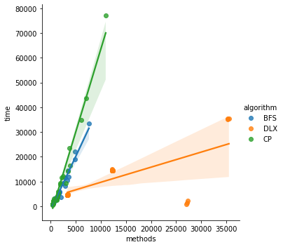

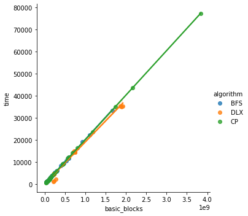

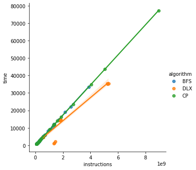

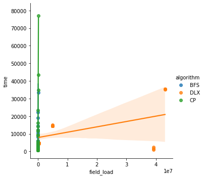

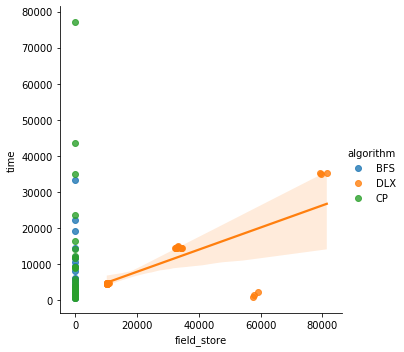

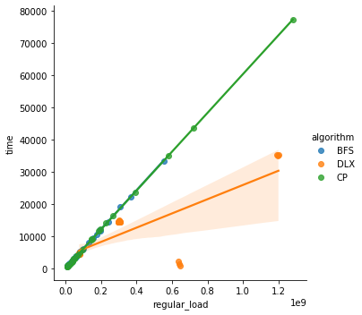

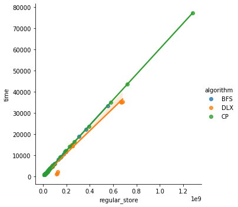

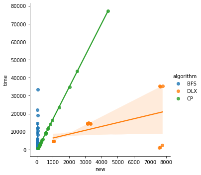

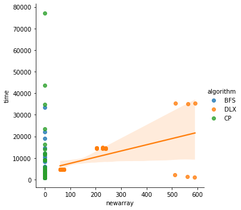

```python
sns.lmplot( x='methods', y='time', data=df, hue='algorithm')
sns.lmplot( x='basic_blocks', y='time', data=df, hue='algorithm')
sns.lmplot( x='instructions', y='time', data=df, hue='algorithm')
sns.lmplot( x='field_load', y='time', data=df, hue='algorithm')
sns.lmplot( x='field_store', y='time', data=df, hue='algorithm')
sns.lmplot( x='regular_load', y='time', data=df, hue='algorithm')
sns.lmplot( x='regular_store', y='time', data=df, hue='algorithm')
sns.lmplot( x='new', y='time', data=df, hue='algorithm')
sns.lmplot( x='newarray', y='time', data=df, hue='algorithm')
```

### From the above graphs we can infer the following have good correlations with time:

**BFS**:

- methods
- basic_blocks
- instructions
- regular_load
- regular_store

**DLX**:

- basic_blocks
- instructions
- regular_store

**CP**:

- methods
- basic_blocks
- instructions
- regular_load
- regular_store
- new

### This means that we can use these to infer the complexity of the problems.

### Since these metrics are only obtainable after running the solvers, we need to correlate them with input variables.

The input variables are: The puzzle, the puzzle size, the position of the last possible unassigned space, and the solver algorithm. The puzzle can be almost anything and it's hard to give it a value. On the other hand, the **puzzle size and unassigned position are good parameters for estimation**.

### Let's analyze them, testing the correlation of the number of unassigned fields to all the above metrics.

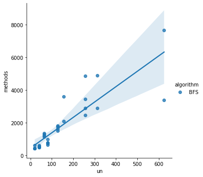

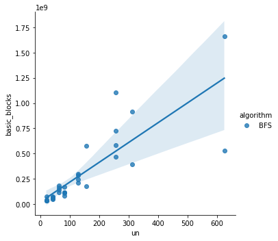

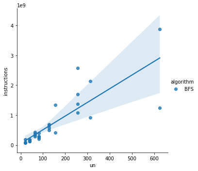

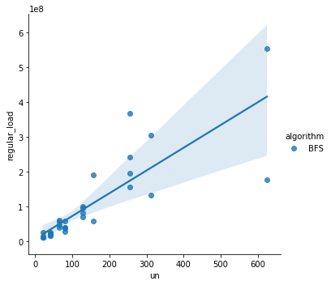

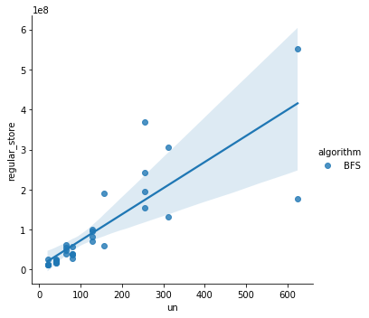

```python
sns.lmplot( x='un', y='methods', data=bfs, fit_reg=True, hue='algorithm')
sns.lmplot( x='un', y='basic_blocks', data=bfs, fit_reg=True, hue='algorithm')
sns.lmplot( x='un', y='instructions', data=bfs, fit_reg=True, hue='algorithm')
sns.lmplot( x='un', y='regular_load', data=bfs, fit_reg=True, hue='algorithm')
sns.lmplot( x='un', y='regular_store', data=bfs, fit_reg=True, hue='algorithm')
```

All of them are very similar if not the same, because they are also correlated between themselves.

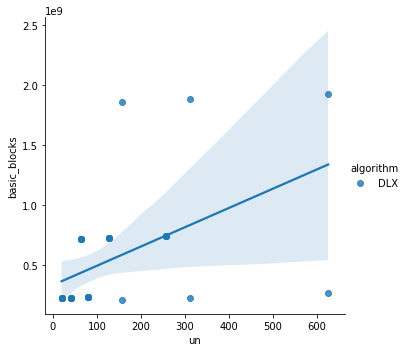

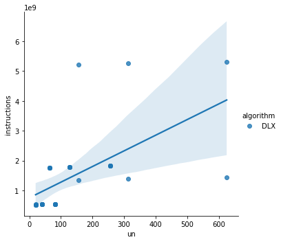

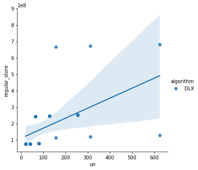

```python
sns.lmplot( x='un', y='basic_blocks', data=dlx, fit_reg=True, hue='algorithm')
sns.lmplot( x='un', y='instructions', data=dlx, fit_reg=True, hue='algorithm')
sns.lmplot( x='un', y='regular_store', data=dlx, fit_reg=True, hue='algorithm')
```

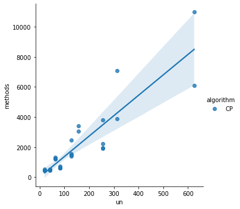

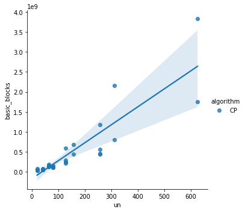

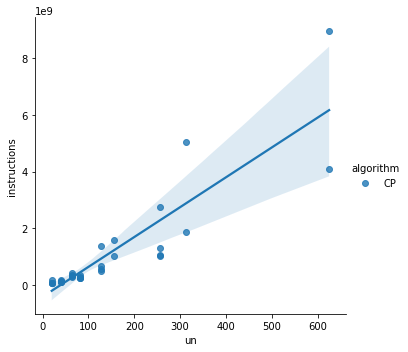

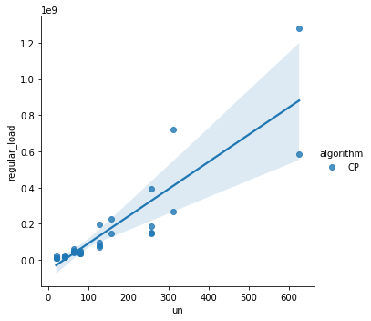

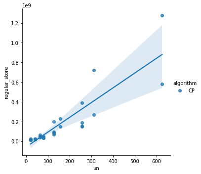

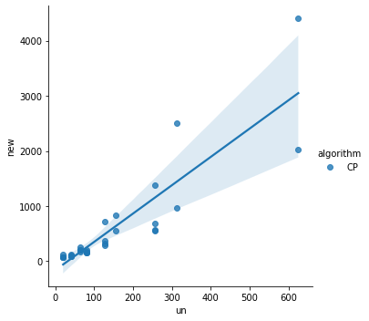

```python
sns.lmplot( x='un', y='methods', data=cp, fit_reg=True, hue='algorithm')
sns.lmplot( x='un', y='basic_blocks', data=cp, fit_reg=True, hue='algorithm')
sns.lmplot( x='un', y='instructions', data=cp, fit_reg=True, hue='algorithm')
sns.lmplot( x='un', y='regular_load', data=cp, fit_reg=True, hue='algorithm')
sns.lmplot( x='un', y='regular_store', data=cp, fit_reg=True, hue='algorithm')
sns.lmplot( x='un', y='new', data=cp, fit_reg=True, hue='algorithm')
```

In all algorithms the metrics are correlated. **This means that using one over another comes down to reducing overhead and increasing performance**.

### By choosing one metric and separating each percentage of unassigned positions, we do not see an improvement, as shown bellow

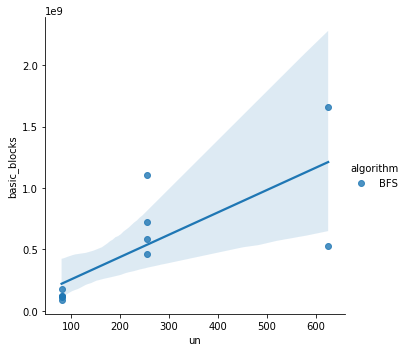

```python
sns.lmplot( x='un', y='basic_blocks', data=max_bfs, fit_reg=True, hue='algorithm')
```

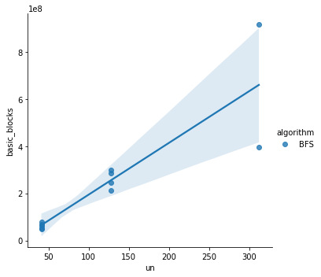

```python
sns.lmplot( x='un', y='basic_blocks', data=half_bfs, fit_reg=True, hue='algorithm')
```

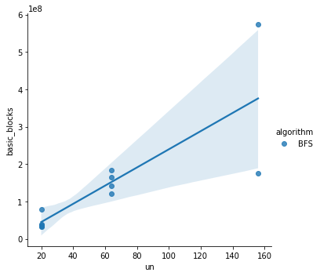

```python
sns.lmplot( x='un', y='basic_blocks', data=quarter_bfs, fit_reg=True, hue='algorithm')
```

### What remains is to fix one puzzle size and do the same

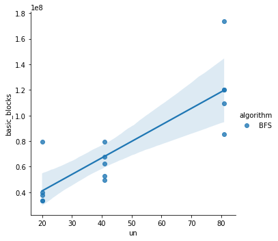

```python
sns.lmplot( x='un', y='basic_blocks', data=bfs_9, fit_reg=True, hue='algorithm')
```

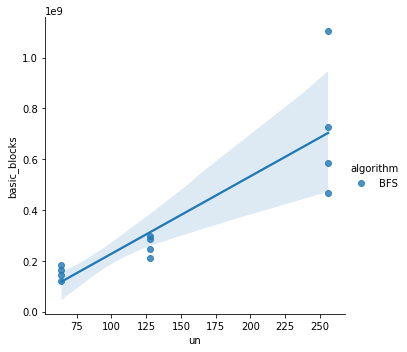

```python
sns.lmplot( x='un', y='basic_blocks', data=bfs_16, fit_reg=True, hue='algorithm')
```

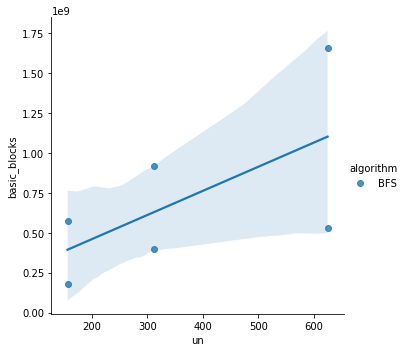

```python
sns.lmplot( x='un', y='basic_blocks', data=bfs_25, fit_reg=True, hue='algorithm')
```

We seem to be able to notice an improvement on 9x9 and 16x16 puzzles.

## Based on these results, we can choose how estimate the problem complexity by its input variables (size, unassigned, solver algorithm)

Our approach will consist of different levels of specificity, analogous to drilling down in SQL, depending on the number of entries we have for each parameter. The model will choose the deepest level it can (i.e. enough samples) while still obtaining a realistic result.

All levels will create a linear regression between the number of unassigned entries and a given metric. From the above results we can say that the number of basic blocks seems like a good metric, but we will test this idea later on.

On each level, a new filter will be created to remove irrelevant data.

### Level 0

The complete dataset will be used for the linear regression. No filter is applied.

```python
from sklearn.linear_model import LinearRegression
```

```
(0, 660.0)
```

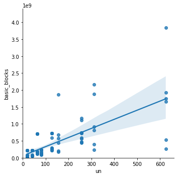

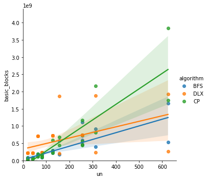

```python
sns.lmplot( x='un', y='basic_blocks', data=df)
plt.ylim(0, 4e9*1.1)
plt.xlim(0, 600*1.1)

sns.lmplot( x='un', y='basic_blocks', data=df, hue='algorithm')
plt.ylim(0, 4e9*1.1)
plt.xlim(0, 600*1.1)
```

```python
reg = LinearRegression().fit(df['un'].to_numpy().reshape(-1, 1), df['basic_blocks'])
reg.coef_[0]
```

```
2690589.7591014365
```

As we can see, it does a reasonable job and estimating the complexity of the problem. It's not perfect as we can see a lot of outliers, but if a deeper level cannot be used that this level is better than nothing. We can see a coefficient of around **2.69e6**.

### Level 1

The dataset will be filtered according to the input solver algorithm.  
Example: BFS

```
(0, 660.0)
```

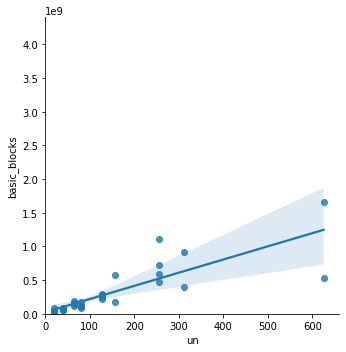

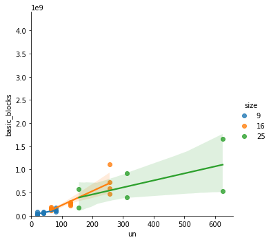

```python
sns.lmplot( x='un', y='basic_blocks', data=bfs)
plt.ylim(0, 4e9*1.1)
plt.xlim(0, 600*1.1)

sns.lmplot( x='un', y='basic_blocks', data=bfs, hue='size')
plt.ylim(0, 4e9*1.1)
plt.xlim(0, 600*1.1)
```

```python
reg = LinearRegression().fit(bfs['un'].to_numpy().reshape(-1, 1), bfs['basic_blocks'])
reg.coef_[0]
```

```
1957782.5289614864
```

*For visualization purposes, the same proportion as level 0 maintained on the first graph.*

We can see that the data points have been refined and provide better information. The regression is better and can estimate the complexity better than on the previous level. The new coefficient is around **1.96e6**, around 0.7e6 lower than before. This means that different algorithms have different trends.

**Note: While outside of the scope of this project, it would be possible, given enough samples, to make a regression out of all coefficients and estimate the coefficient for new unknown sizes, to estimate the complexity given the *un*. This way, even if data was not available, a sufficiently good prediction could be made.**

### Level 2

The dataset will be filtered according to the input solver algorithm and puzzle size.  
Example: BFS with 9x9

```
(0, 92.3076923076923)
```

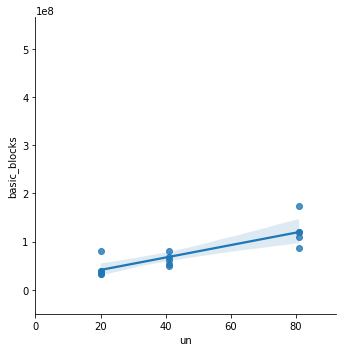

```python
sns.lmplot( x='un', y='basic_blocks', data=bfs_9)
plt.ylim(-0.5e8, -0.5e8 + 4e9/6.5)
plt.xlim(0, 600/6.5)
```

```python
reg = LinearRegression().fit(bfs_9['un'].to_numpy().reshape(-1, 1), bfs_9['basic_blocks'])
reg.coef_[0]
```

```
1290287.610586602
```

*Again, the same proportions were used for comparison purposes.*  
As we can see, at this level, un is very good at estimating the complexity of problem. We were able to settle at **1.29e6** with minimal error. This is about half than that of the first level. It means that by removing irrelevant samples from the dataset, we were able to find a much more accurate coefficient in which *un* evolves given the other parameters.

## Intermediate conclusion

On a first look, it seems that this approach is very good at finding the right relation between parameters and complexity, while only relying on a simple metric which is the number of basic blocks.

### We now need to test it on other puzzle sizes for level 2

```
(0, 300.0)
```

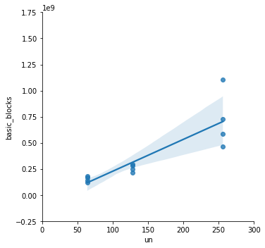

```python
sns.lmplot( x='un', y='basic_blocks', data=bfs_16)
plt.ylim(-0.25e9, -0.25e9 + 4e9/2)
plt.xlim(0, 600/2)
```

```python
reg = LinearRegression().fit(bfs_16['un'].to_numpy().reshape(-1, 1), bfs_16['basic_blocks'])
reg.coef_[0]
```

```
3051147.455357143
```

```
(0, 660.0)
```

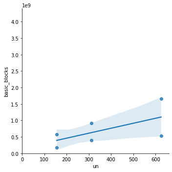

```python
sns.lmplot( x='un', y='basic_blocks', data=bfs_25)
plt.ylim(0, 4e9*1.1)
plt.xlim(0, 600*1.1)
```

```python
reg = LinearRegression().fit(bfs_25['un'].to_numpy().reshape(-1, 1), bfs_25['basic_blocks'])
reg.coef_[0]
```

```
1511561.9548552877
```

The coefficients are:  
At level 1: **1.96e6**  
At level 2, 9x9: **1.29e6**  
At level 2, 16x16: **3.05e6**  
At level 2, 25x25: **1.51e6**

Even with some error on the 25x25 due to a small amount of samples, it's still better to use this level than to stay at level 1, which would give us a worse result overall.

### And now we repeat Level 1 with the other algorithms

## CP

Level 0 for comparison purposes.

```
(0, 660.0)
```

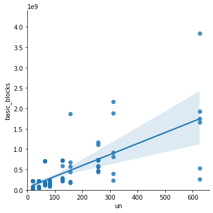

```python
sns.lmplot( x='un', y='basic_blocks', data=df)
plt.ylim(0, 4e9*1.1)
plt.xlim(0, 600*1.1)
```

```python
reg = LinearRegression().fit(df['un'].to_numpy().reshape(-1, 1), df['basic_blocks'])
reg.coef_[0]
```

```
2690589.7591014365
```

### Level 1

```
(0, 660.0)
```

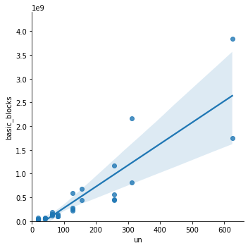

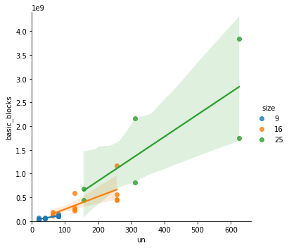

```python
sns.lmplot( x='un', y='basic_blocks', data=cp)
plt.ylim(0, 4e9*1.1)
plt.xlim(0, 600*1.1)

sns.lmplot( x='un', y='basic_blocks', data=cp, hue='size')
plt.ylim(0, 4e9*1.1)
plt.xlim(0, 600*1.1)
```

```python
reg = LinearRegression().fit(cp['un'].to_numpy().reshape(-1, 1), cp['basic_blocks'])
reg.coef_[0]
```

```
4507001.763031414
```

We can see that level 1 for CP follows a similar evolution (not with the same coefficient, but a similar logic) to level 1 for BFS.

Comparing to level 0, we now have a coefficient of **4.51e6** instead of **2.69e6**.

### Level 2

```
(0, 100.0)
```

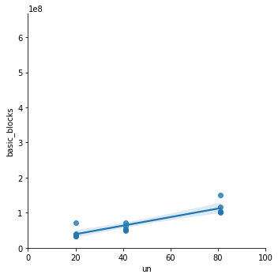

```python
sns.lmplot( x='un', y='basic_blocks', data=cp_9)
plt.ylim(0, 4e9/6)
plt.xlim(0, 600/6)
```

```python
reg = LinearRegression().fit(cp_9['un'].to_numpy().reshape(-1, 1), cp_9['basic_blocks'])
reg.coef_[0]
```

```
1217211.0309961815
```

```
(0, 300.0)
```

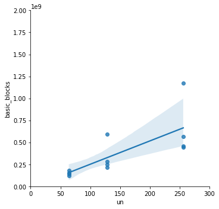

```python
sns.lmplot( x='un', y='basic_blocks', data=cp_16)
plt.ylim(0, 4e9/2)
plt.xlim(0, 600/2)
```

```python
reg = LinearRegression().fit(cp_16['un'].to_numpy().reshape(-1, 1), cp_16['basic_blocks'])
reg.coef_[0]
```

```
2649311.58984375
```

```
(0, 660.0)
```

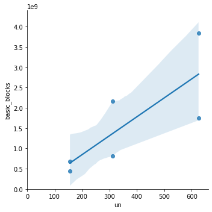

```python
sns.lmplot( x='un', y='basic_blocks', data=cp_25)
plt.ylim(0, 4e9*1.1)
plt.xlim(0, 600*1.1)
```

```python
reg = LinearRegression().fit(cp_25['un'].to_numpy().reshape(-1, 1), cp_25['basic_blocks'])
reg.coef_[0]
```

```
4669857.882462762
```

Which shows there's a lot of coefficient growth the bigger the size of the puzzle.

## DLX

Level 0 for comparison purposes.

```
(0, 660.0)
```

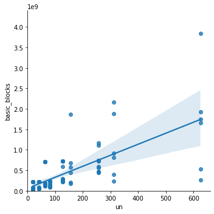

```python
sns.lmplot( x='un', y='basic_blocks', data=df)
plt.ylim(0, 4e9*1.1)
plt.xlim(0, 600*1.1)
```

```python
reg = LinearRegression().fit(df['un'].to_numpy().reshape(-1, 1), df['basic_blocks'])
reg.coef_[0]
```

```
2690589.7591014365
```

### Level 1

```
(0, 660.0)
```

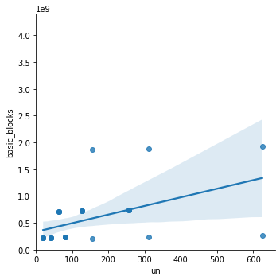

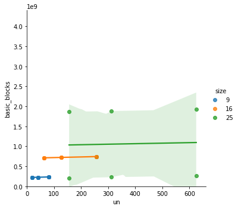

```python
sns.lmplot( x='un', y='basic_blocks', data=dlx)
plt.ylim(0, 4e9*1.1)
plt.xlim(0, 600*1.1)

sns.lmplot( x='un', y='basic_blocks', data=dlx, hue='size')
plt.ylim(0, 4e9*1.1)
plt.xlim(0, 600*1.1)
```

```python
reg = LinearRegression().fit(dlx['un'].to_numpy().reshape(-1, 1), dlx['basic_blocks'])
reg.coef_[0]
```

```
1606984.9853114157
```

This algorithm seems to have a different pattern of scaling compared to BFS and CP. The size seems like a more important factor for this algorithm, rather than the number of unassigned entries.

### Level 2

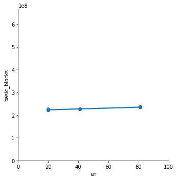

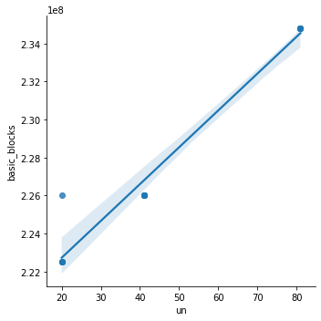

```python
sns.lmplot( x='un', y='basic_blocks', data=dlx_9)
plt.ylim(0, 4e9/6)
plt.xlim(0, 600/6)
sns.lmplot( x='un', y='basic_blocks', data=dlx_9)
```

```python
reg = LinearRegression().fit(dlx_9['un'].to_numpy().reshape(-1, 1), dlx_9['basic_blocks'])
reg.coef_[0]
```

```
193782.04953141272
```

*The graph above uses the same scale as always to allow comparisons, the second graph uses its own scale to demonstrate that there is still a increase with un*

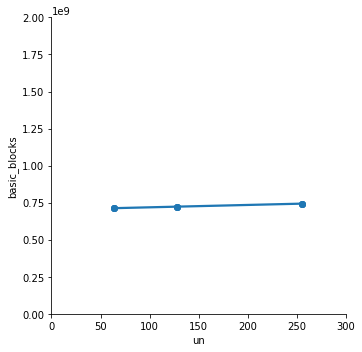

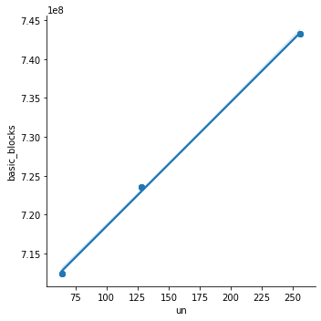

```python
sns.lmplot( x='un', y='basic_blocks', data=dlx_16)
plt.ylim(0, 4e9/2)
plt.xlim(0, 600/2)
sns.lmplot( x='un', y='basic_blocks', data=dlx_16)
```

```python
reg = LinearRegression().fit(dlx_16['un'].to_numpy().reshape(-1, 1), dlx_16['basic_blocks'])
reg.coef_[0]
```

```
159684.08147321432
```

*The graph above uses the same scale as always to allow comparisons, the second graph uses its own scale to demonstrate that there is still a increase with un*

```
(0, 660.0)
```

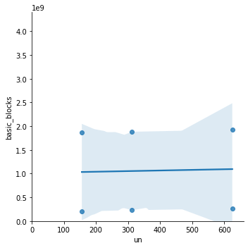

```python
sns.lmplot( x='un', y='basic_blocks', data=dlx_25)
plt.ylim(0, 4e9*1.1)
plt.xlim(0, 600*1.1)
```

```python
reg = LinearRegression().fit(dlx_25['un'].to_numpy().reshape(-1, 1), dlx_25['basic_blocks'])
reg.coef_[0]
```

```
130017.09150193095
```

The coefficients are:  
At level 1: **1.61e6**  
At level 2, 9x9: **1.94e5**  
At level 2, 16x16: **1.60e5**  
At level 2, 25x25: **1.30e5**

### Overall we conclude the following values:

[output not shown]

## Conclusion

This approach to levels seems like a good way to increase the precision of the estimation, specially in level 2. In level 1, there's a problem with the DLX algorithm, since the scaling factor is much lower in general but the variation in the y axis gives it an apparent higher coefficient than there actually is. Nevertheless, it's still better than level 0. For higher precision, a different approach may need to be taken for DLX in the future for level 1.